# FinalProjectMatthew

**Introduction: An analysis of top rated animes**

Anime was first introduced in Japan in the mid 1900's and has gained traction through its exposure to western audiences primarily through Naruto, One Piece, and a few other larger animes. Since then, anime has been growing rapidly and has become common place in the lives of many people throughout the world. In this turorial, we are going to take a look at a few basic statistics like episode number and genre to determine which combination of episodes/genres result in the highest number of community members and the highest ratings. Luckily, myanimelist, one of the world's largest platforms for discussing and rating animes has databases that we can easily download and access.

```python
import pandas as pd
import numpy as np
import matplotlib.pyplot as plt
from sklearn import preprocessing, svm
from sklearn.model_selection import train_test_split
from sklearn.linear_model import LinearRegression
```

```python
anime = pd.read_csv("anime.csv")
anime
```

|  | anime_id | name | genre | type | episodes | rating | members |
| --- | --- | --- | --- | --- | --- | --- | --- |
| 0 | 32281 | Kimi no Na wa. | Drama, Romance, School, Supernatural | Movie | 1 | 9.37 | 200630 |
| 1 | 5114 | Fullmetal Alchemist: Brotherhood | Action, Adventure, Drama, Fantasy, Magic, Mili... | TV | 64 | 9.26 | 793665 |
| 2 | 28977 | Gintama° | Action, Comedy, Historical, Parody, Samurai, S... | TV | 51 | 9.25 | 114262 |
| 3 | 9253 | Steins;Gate | Sci-Fi, Thriller | TV | 24 | 9.17 | 673572 |
| 4 | 9969 | Gintama&#039; | Action, Comedy, Historical, Parody, Samurai, S... | TV | 51 | 9.16 | 151266 |
| ... | ... | ... | ... | ... | ... | ... | ... |
| 12289 | 9316 | Toushindai My Lover: Minami tai Mecha-Minami | Hentai | OVA | 1 | 4.15 | 211 |
| 12290 | 5543 | Under World | Hentai | OVA | 1 | 4.28 | 183 |
| 12291 | 5621 | Violence Gekiga David no Hoshi | Hentai | OVA | 4 | 4.88 | 219 |
| 12292 | 6133 | Violence Gekiga Shin David no Hoshi: Inma Dens... | Hentai | OVA | 1 | 4.98 | 175 |
| 12293 | 26081 | Yasuji no Pornorama: Yacchimae!! | Hentai | Movie | 1 | 5.46 | 142 |

12294 rows × 7 columns

**In our anime dataset above we have:**

- an anime_id representing the id of the anime on myanimelist
- the name of the anime in English/Japanese
- a list of all genres for that anime
- the type of anime
- the number of episodes in that anime
- the overall ratings of the anime out of 10
- the number of community members who have joined that community on myanimelist

**Tidying the Data**

For this section below, we will refer to TV Series/Movie types of animes as the general 'anime'.

```python
set1 = anime[anime["type"].str.contains("OVA") == False]
set1 = set1[anime["type"].str.contains("ONA") == False]
set1 = set1[anime["type"].str.contains("Special") == False]
set1 = set1[set1['members'] > 1000]

set1
```

|  | anime_id | name | genre | type | episodes | rating | members |
| --- | --- | --- | --- | --- | --- | --- | --- |
| 0 | 32281 | Kimi no Na wa. | Drama, Romance, School, Supernatural | Movie | 1 | 9.37 | 200630 |
| 1 | 5114 | Fullmetal Alchemist: Brotherhood | Action, Adventure, Drama, Fantasy, Magic, Mili... | TV | 64 | 9.26 | 793665 |
| 2 | 28977 | Gintama° | Action, Comedy, Historical, Parody, Samurai, S... | TV | 51 | 9.25 | 114262 |
| 3 | 9253 | Steins;Gate | Sci-Fi, Thriller | TV | 24 | 9.17 | 673572 |
| 4 | 9969 | Gintama&#039; | Action, Comedy, Historical, Parody, Samurai, S... | TV | 51 | 9.16 | 151266 |
| ... | ... | ... | ... | ... | ... | ... | ... |
| 11154 | 3220 | Kanashimi no Belladonna | Drama, Hentai | Movie | 1 | 7.28 | 6599 |
| 11605 | 2359 | Choujin Densetsu Urotsukidouji Movie | Action, Demons, Drama, Hentai | Movie | 1 | 6.37 | 2545 |
| 11665 | 2360 | Choujin Densetsu Urotsukidouji 2 | Demons, Fantasy, Hentai, Horror, Sci-Fi | Movie | 1 | 6.28 | 1830 |
| 11738 | 3038 | Senya Ichiya Monogatari | Fantasy, Hentai | Movie | 1 | 6.18 | 1394 |
| 11805 | 2755 | Cleopatra | Hentai, Historical | Movie | 1 | 6.06 | 1709 |

3618 rows × 7 columns

**Exploratory Data Analysis**

Generally speaking, someone who rated the anime may not be a part of the community, however, people who feel strongly about animes are more likely to be a part of the community. Therefore, the first thing we want to do is compare whether or not there is a correlation between ratings and community members to see if higher ratings really attract more people to be a part of the community. We are going to compare the top 250 animes to the entire anime collection as a whole to see what trends there are for top tier animes versus all animes.

**Part 1**

**First let's look at the top 250 animes and their communities versus their ratings**

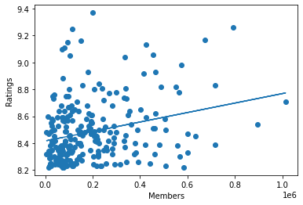

```
Number of anime with ratings of (9.0+) out of top 250 rated animes: 250
```

```python
#On how to make a scatter plot, use https://stackoverflow.com/questions/64826012/how-to-create-coordinate-x-y-with-two-list-for-a-scatter-plot-matplotlib for more information
x = set1['members']
x = x[0:250]
plt.xlabel("Members")
plt.ylabel("Ratings")
y = set1['rating']
y = y[0:250]
plt.scatter(x, y)

m, b = np.polyfit(x, y, 1)
plt.plot(x, m*x + b)
plt.show()

i = 0
j = 0
for ele in x:
    if ele > 9.0:
        i+=1


print("Number of anime with ratings of (9.0+) out of top 250 rated animes: " + str(i))
```

**Hypothesis Testing**

Let's cross verify our prediction and see how a regression model does in trying to predict anime ratings based on communities.

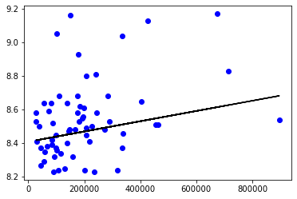

```python
#On how to create a linear regression, https://www.geeksforgeeks.org/python-linear-regression-using-sklearn/ provides a great quick tutorial

set1500 = set1[:][:250]
X = np.array(set1500['members']).reshape(-1, 1)
y = np.array(set1500['rating']).reshape(-1, 1)

X_train, X_test, y_train, y_test = train_test_split(X, y, test_size = 0.25)

regr = linear_model.LinearRegression()
regr.fit(X_train, y_train)


y_pred = regr.predict(X_test)
plt.scatter(X_test, y_test, color ='blue')
plt.plot(X_test, y_pred, color ='k')

plt.show()
```

Here, we used a linear regression model to attempt to model member count versus projected ratings of the top 250 rated animes because of its ease of being able to see the results of our model.

Looking at our regression line, we can clearly see that it does not do a very good job of projecting ratings given a certain member count. For instance, the regression line predicts that as member count goes up, so does ratings. However, looking at most of the highest rated animes, the member counts are not actually as high as many others. Other models like the decision tree model could do very slightly better than our linear regression model, however, in this case, we can see through the linear regression's performance that the data is too underfitting to provide a good way of predicting the anime's rating.

This helps us conclude that member count just as predicted in our analysis prior is not a good indicator of anime rating success when it comes to the top animes.

**Finally, let's take a look at whether or not this is consistent with all animes**

```
Average rating: 7.203443746430611
Average member ct: 51350.78358208955
```

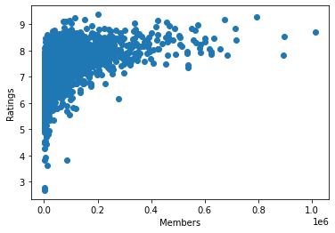

```python
x = set1['members']
y = set1['rating']

avgr = np.nanmean(y)
avgm = np.nanmean(x)

print("Average rating: " + str(avgr))
print("Average member ct: " + str(avgm))

plt.clf()
plt.scatter(x, y)
plt.xlabel("Members")
plt.ylabel("Ratings")


plt.show()
```

Looking at our distribution of members versus ratings for animes, we can see that though we concluded that at the top, members do not matter to determine ratings, however, it does seem that generally for higher rated animes compared to the average (7.2), there is a much higher liklihood that one of them will have an above average member count ( > 51351).

Thus, we can conclude in this situation that generally across all animes we are looking at, there seems to be a positive relationship between ratings and member count though it does seem to be very weak as many anime with higher ratings still have smaller than average communities.

**Testing the anime genres**

```python
genres = set1['genre']
genres = genres[0:250]
freq = {"Drama": 0,
        "Romance": 0,
        "School": 0,
        "Supernatural": 0,
        "Action": 0,
        "Adventure": 0,
        "Drama": 0,
        "Fantasy": 0,
        "Magic": 0,
        "Military": 0,
        "Shounen": 0,
        "Comedy": 0,
        "Historical": 0,
        "Parody": 0,
        "Samurai": 0,
        "Sci-Fi": 0,
        "Thriller": 0,
        "Sports": 0,
        "Super Power": 0,
        "Slice of Life": 0,
        "Mecha": 0,
        "Music": 0,
        "Mystery": 0,
        "Seinen": 0,
        "Space": 0,
        "Vampire": 0,
        "Shoujo": 0,
        "Horror": 0,
        "Police": 0,
        "Psychological": 0,
        "Ecchi": 0,
        "Josei": 0,
        "Shounen Ai": 0,
        "Game": 0,
        "Martial Arts": 0,
        "Demons": 0,
        "Dementia": 0,
        "Harem": 0,
        "Cars": 0
       }
rats = []
for num in y:
    rats.append(num)
j = 0
for elem in genres:
    all = elem.split(", ")
    rat = rats[j]
    for i in range(len(all)):
        add = all[i]
        freq[add]+=(1 + rat)
    j+=1

freq
```

```
{'Drama': 1025.53,
 'Romance': 585.12,
 'School': 418.72000000000014,
 'Supernatural': 563.42,
 'Action': 817.3100000000007,
 'Adventure': 540.55,
 'Fantasy': 550.08,
 'Magic': 169.19,
 'Military': 114.77,
 'Shounen': 743.5500000000003,
 'Comedy': 1022.6700000000002,
 'Historical': 307.05000000000007,
 'Parody': 88.94,
 'Samurai': 98.21000000000001,
 'Sci-Fi': 411.87999999999994,
 'Thriller': 181.17000000000002,
 'Sports': 294.77000000000004,
 'Super Power': 133.87,
 'Slice of Life': 418.2100000000001,
 'Mecha': 114.37000000000002,
 'Music': 94.42999999999999,
 'Mystery': 369.94000000000005,
 'Seinen': 294.1900000000001,
 'Space': 66.34,
 'Vampire': 47.879999999999995,
 'Shoujo': 160.2,
 'Horror': 66.29,
 'Police': 122.45,
 'Psychological': 254.97,
 'Ecchi': 38.0,
 'Josei': 94.19,
 'Shounen Ai': 28.08,
 'Game': 56.26,
 'Martial Arts': 37.53,
 'Demons': 65.71,
 'Dementia': 28.0,
 'Harem': 18.69,
 'Cars': 37.09}
```

With our results, we see that among the top 250 highest rated anime, Drama, Comedy, and Action are the 3 most popular and highly rated genres of anime. This is important information to know because this can help us design our own model of predicting anime ratings given a set of genres that anime will be based off of.

```
Number of high rated drama animes: 587
Number of high rated comedy animes: 620
Number of high rated action animes: 337
```

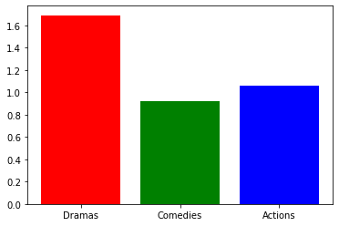

```python
#Use https://www.geeksforgeeks.org/graph-plotting-in-python-set-1/ to refer to how to create bar graphs
dcount = 0
ccount = 0
acount = 0
dramact = 0
comedyct = 0
actionct = 0
for index, ani in set1.iterrows():
    g = str(ani['genre'])
    if 'Drama' in g and ani['rating'] > 7.203:
        dcount+=1
    elif 'Comedy' in g and ani['rating'] > 7.203:
        ccount+=1
    elif 'Action' in g and ani['rating'] > 7.203:
        acount+=1
    elif 'Drama' in g:
        dramact+=1
    elif 'Comedy' in g:
        comedyct+=1
    elif 'Action' in g:
        actionct+=1

print("Number of high rated drama animes: " + str(dcount))
print("Number of high rated comedy animes: " + str(ccount))
print("Number of high rated action animes: " + str(acount))

left = [1, 2, 3]
#Divide to determine which genres have the best ratings vs which are just very common
height = [dcount/dramact, ccount/comedyct, acount/actionct]
tick_label = ["Dramas", "Comedies", "Actions"]
plt.bar(left, height, tick_label = tick_label,
        width = 0.8, color = ['red', 'green', 'blue'])

plt.show()
```

**Part 1 Insights**

Now that we have run our analysis on member counts and anime genres on the ratings of a particular anime, we can draw some conclusions about the importance of members and genres on the ratings of an anime.

Second, through filtering and analysis of all genres found within the top 250 anime, we see that there are 3 significant genres that consistently rank in the most popular/highest rated being Drama, Comedy, and Action. We concluded that among the three, drama and action were the 2 genres that consistently rated the highest. Therefore, if an anime contained either Drama or Action, we could conclude that it has a higher chance than other genres of having success ratings wise. Additionally, we concluded that though comedy was a high rated anime genre, it appeared more often in animes resulting in it being more significant than other genres.

**Part 2**

**Now let's look at the ONA/OVA's**

We will run through the same steps that we did for the TV Series/Movies and will refer to 'animes' as animes regarding the type ONA, OVA and Specials.

```python
set2 = anime[anime["type"].str.contains("TV") == False]
set2 = set2[anime["type"].str.contains("Movie") == False]
set2 = set2[set2['members'] > 1000]

set2
```

|  | anime_id | name | genre | type | episodes | rating | members |
| --- | --- | --- | --- | --- | --- | --- | --- |
| 7 | 820 | Ginga Eiyuu Densetsu | Drama, Military, Sci-Fi, Space | OVA | 110 | 9.11 | 80679 |
| 21 | 44 | Rurouni Kenshin: Meiji Kenkaku Romantan - Tsui... | Action, Drama, Historical, Martial Arts, Roman... | OVA | 4 | 8.83 | 129307 |
| 41 | 32366 | Gintama°: Aizome Kaori-hen | Comedy, Parody | OVA | 2 | 8.69 | 16947 |
| 48 | 21329 | Mushishi Special: Hihamukage | Adventure, Fantasy, Historical, Mystery, Seine... | Special | 1 | 8.66 | 49036 |
| 52 | 30709 | Kamisama Hajimemashita: Kako-hen | Comedy, Demons, Fantasy, Shoujo, Supernatural | OVA | 4 | 8.64 | 33422 |
| ... | ... | ... | ... | ... | ... | ... | ... |
| 12212 | 3635 | Advancer Tina | Hentai, Sci-Fi, Space | OVA | 1 | 5.16 | 1487 |
| 12213 | 4866 | Pico x CoCo x Chico | Hentai, Yaoi | OVA | 1 | 5.16 | 27411 |
| 12217 | 1639 | Boku no Pico | Hentai, Yaoi | OVA | 1 | 5.13 | 57355 |
| 12223 | 23171 | Mahou Shoujo wa Kiss Shite Kawaru | Hentai | OVA | 1 | 5.09 | 1081 |
| 12227 | 4601 | Fairy Forest Remi-chan | Hentai | OVA | 1 | 5.04 | 1060 |

3420 rows × 7 columns

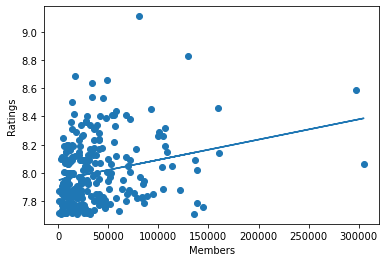

```
Number of anime with ratings of (9.0+) out of top 250 rated animes: 250
```

```python
x = set2['members']
x = x[0:250]
plt.xlabel("Members")
plt.ylabel("Ratings")
y = set2['rating']
y = y[0:250]
plt.scatter(x, y)

m, b = np.polyfit(x, y, 1)
plt.plot(x, m*x + b)
plt.show()

i = 0
j = 0
for ele in x:
    if ele > 9.0:
        i+=1


print("Number of anime with ratings of (9.0+) out of top 250 rated animes: " + str(i))
```

**Hypothesis Testing**

Let's cross verify our prediction and see how a regression model does in trying to predict anime ratings based on communities.

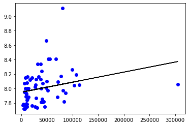

```python
#On how to create a linear regression, https://www.geeksforgeeks.org/python-linear-regression-using-sklearn/ provides a great quick tutorial

set2500 = set2[:][:250]
X = np.array(set2500['members']).reshape(-1, 1)
y = np.array(set2500['rating']).reshape(-1, 1)

X_train, X_test, y_train, y_test = train_test_split(X, y, test_size = 0.25)

regr = linear_model.LinearRegression()
regr.fit(X_train, y_train)


y_pred = regr.predict(X_test)
plt.scatter(X_test, y_test, color ='blue')
plt.plot(X_test, y_pred, color ='k')

plt.show()
```

Again, we used a linear regression model to attempt to model member count versus projected ratings of the top 250 rated animes because of its ease of being able to see the results of our model.

Looking at our regression line, we can again clearly see that it does not do a very good job of projecting ratings given a certain member count. It falls into the same problems that TV Series/Movies fall into in that the member count is not a good fit at predicting rating numbers.

This verifies again that membership is not a good indicator of how well rated an anime is.

**Finally, let's take a look at whether or not this is consistent with all animes**

```
Average rating: 6.717247868274037
Average member ct: 10306.280116959064
```

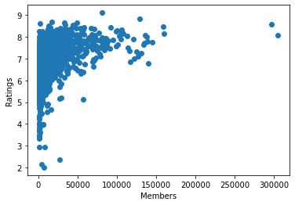

```python
x = set2['members']
y = set2['rating']

avgr = np.nanmean(y)
avgm = np.nanmean(x)

print("Average rating: " + str(avgr))
print("Average member ct: " + str(avgm))

plt.clf()
plt.scatter(x, y)
plt.xlabel("Members")
plt.ylabel("Ratings")


plt.show()
```

We again see the same sort of distribution of ratings vs members which tells us that as member count increases, there is a higher liklihood that an anime's rating increases. Looking at most of the highest member counts, they all come from animes that have ratings of over ~7.

Additionally, we can see that there is a stark difference in quality of OVA/ONA/Specials and TV Series/Movies. Average ratings are down from 7.203 to 6.717 and member counts are down from fifty thousand to ten thousand. We can see that both popularity and quality of the animes are down.

```python
genres = set2['genre']
genres = genres[0:250]
freq = {"Drama": 0,
        "Romance": 0,
        "School": 0,
        "Supernatural": 0,
        "Action": 0,
        "Adventure": 0,
        "Drama": 0,
        "Fantasy": 0,
        "Magic": 0,
        "Military": 0,
        "Shounen": 0,
        "Comedy": 0,
        "Historical": 0,
        "Parody": 0,
        "Samurai": 0,
        "Sci-Fi": 0,
        "Thriller": 0,
        "Sports": 0,
        "Super Power": 0,
        "Slice of Life": 0,
        "Mecha": 0,
        "Music": 0,
        "Mystery": 0,
        "Seinen": 0,
        "Space": 0,
        "Vampire": 0,
        "Shoujo": 0,
        "Horror": 0,
        "Police": 0,
        "Psychological": 0,
        "Ecchi": 0,
        "Josei": 0,
        "Shounen Ai": 0,
        "Game": 0,
        "Martial Arts": 0,
        "Demons": 0,
        "Dementia": 0,
        "Harem": 0,
        "Cars": 0,
        "Shoujo Ai": 0,
        "Kids": 0
       }
rats = []
for num in y:
    rats.append(num)
j = 0

for elem in genres:
    all = elem.split(", ")
    rat = rats[j]
    for i in range(len(all)):
        add = all[i]
        freq[add]+=(1 + rat)
    j+=1

freq
```

```
{'Drama': 480.90999999999985,
 'Romance': 394.9700000000001,
 'School': 464.20000000000005,
 'Supernatural': 415.2800000000002,
 'Action': 839.4400000000003,
 'Adventure': 496.6600000000001,
 'Fantasy': 460.75999999999993,
 'Magic': 107.56,
 'Military': 217.67999999999998,
 'Shounen': 854.9900000000002,
 'Comedy': 1263.5900000000001,
 'Historical': 209.92999999999995,
 'Parody': 216.13,
 'Samurai': 73.97,
 'Sci-Fi': 471.4900000000001,
 'Thriller': 36.43,
 'Sports': 207.12000000000003,
 'Super Power': 207.97,
 'Slice of Life': 359.90999999999997,
 'Mecha': 207.26000000000002,
 'Music': 107.71,
 'Mystery': 270.53,
 'Seinen': 145.14,
 'Space': 145.33,
 'Vampire': 45.15,
 'Shoujo': 99.78999999999999,
 'Horror': 45.31999999999999,
 'Police': 89.5,
 'Psychological': 71.73000000000002,
 'Ecchi': 89.03,
 'Josei': 35.69,
 'Shounen Ai': 44.85,
 'Game': 9.09,
 'Martial Arts': 55.11000000000001,
 'Demons': 63.61,
 'Dementia': 9.06,
 'Harem': 53.38,
 'Cars': 8.74,
 'Shoujo Ai': 26.79,
 'Kids': 8.940000000000001}
```

With our results, we see that among the top 250 highest rated anime, Action, Shounen, and Comedy are the 3 most popular and highly rated genres of anime. This is important information to know because this can help us design our own model of predicting anime ratings given a set of genres that anime will be based off of.

```
Number of high rated shounen animes: 753
Number of high rated comedy animes: 643
Number of high rated action animes: 620
```

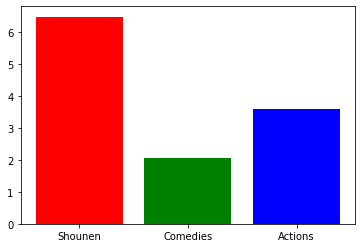

```python
#Use https://www.geeksforgeeks.org/graph-plotting-in-python-set-1/ to refer to how to create bar graphs
scount = 0
ccount = 0
acount = 0
shounenct = 0
comedyct = 0
actionct = 0
#Finds all animes that have a higher than average rating while being in our most frequent/highest rated list
for index, an in set1.iterrows():
    g = str(an['genre'])
    if 'Shounen' in g and an['rating'] > 6.717:
        scount+=1
    elif 'Action' in g and an['rating'] > 6.717:
        ccount+=1
    elif 'Comedy' in g and an['rating'] > 6.717:
        acount+=1
    elif 'Shounen' in g:
        shounenct+=1
    elif 'Comedy' in g:
        comedyct+=1
    elif 'Action' in g:
        actionct+=1

print("Number of high rated shounen animes: " + str(scount))
print("Number of high rated comedy animes: " + str(ccount))
print("Number of high rated action animes: " + str(acount))

#Visualize our data
left = [1, 2, 3]
#Divide to determine which genres have the best ratings vs which have the most occurrences
height = [scount/shounenct, ccount/comedyct, acount/actionct]
tick_label = ["Shounen", "Comedies", "Actions"]
plt.bar(left, height, tick_label = tick_label,
        width = 0.8, color = ['red', 'green', 'blue'])

plt.show()
```

**CONCLUSION**

Since the 2000s, anime has been a rapidly growing industry with more studios and animes being released every season alongside a more widespread audience than just Japan where it originated. We managed to gain some valuable insight into anime communities and genres through this tutorial through the data science pipeline process. Even if anime is not something you are heavily interested in, the methods used to analyze the data can be applied to many other different types of data as well as the ideas behind why we used those methods of analysis.

Happy exploring -Matthew